# Project: Investigate No show appointment Dataset

Introduction Dataset Description This dataset collects information from 100k medical appointments in Brazil and is focused on the question of whether or not patients show up for their appointment. A number of characteristics about the patient are included in each row.

● ‘ScheduledDay’ tells us on what day the patient set up their appointment.

● ‘Neighborhood’ indicates the location of the hospital.

● ‘Scholarship’ indicates whether or not the patient is enrolled in Brasilian welfare Question(s) for Analysis

### we will try to know What factors are important for us to know in order to predict if a patient will show up for their scheduled appointment?

Questions we are trying to answer :

1 - what is the overall appointment show-up vs. no show-up rate

2 - what are the most feature that matter the most of ('Age', 'being alcoholic','Having an SMS', 'Gender', 'Scholarship'), to make the patient make it to his appiontment?

```python
# Use this cell to set up import statements for all of the packages that you plan to use.
import pandas as pd
import numpy as np
import matplotlib.pyplot as plt
import seaborn as sns
# Remember to include a 'magic word' so that your visualizations are plotted
#   inline with the notebook. See this page for more:
#   http://ipython.readthedocs.io/en/stable/interactive/magics.html
%matplotlib inline
```

## Data Wrangling

> **Tip**: In this section of the report, you will load in the data, check for cleanliness, and then trim and clean your dataset for analysis. Make sure that you **document your data cleaning steps in mark-down cells precisely and justify your cleaning decisions.**

### General Properties

```python
# Load your data and print out a few lines. Perform operations to inspect data
#   types and look for instances of missing or possibly errant data.
```

```python
df = pd.read_csv('noshowappointments-kagglev2-may-2016.csv')
df.head()
```

|  | PatientId | AppointmentID | Gender | ScheduledDay | AppointmentDay | Age | Neighbourhood | Scholarship | Hipertension | Diabetes | Alcoholism | Handcap | SMS_received | No-show |
| --- | --- | --- | --- | --- | --- | --- | --- | --- | --- | --- | --- | --- | --- | --- |
| 0 | 2.987250e+13 | 5642903 | F | 2016-04-29T18:38:08Z | 2016-04-29T00:00:00Z | 62 | JARDIM DA PENHA | 0 | 1 | 0 | 0 | 0 | 0 | No |
| 1 | 5.589978e+14 | 5642503 | M | 2016-04-29T16:08:27Z | 2016-04-29T00:00:00Z | 56 | JARDIM DA PENHA | 0 | 0 | 0 | 0 | 0 | 0 | No |
| 2 | 4.262962e+12 | 5642549 | F | 2016-04-29T16:19:04Z | 2016-04-29T00:00:00Z | 62 | MATA DA PRAIA | 0 | 0 | 0 | 0 | 0 | 0 | No |
| 3 | 8.679512e+11 | 5642828 | F | 2016-04-29T17:29:31Z | 2016-04-29T00:00:00Z | 8 | PONTAL DE CAMBURI | 0 | 0 | 0 | 0 | 0 | 0 | No |
| 4 | 8.841186e+12 | 5642494 | F | 2016-04-29T16:07:23Z | 2016-04-29T00:00:00Z | 56 | JARDIM DA PENHA | 0 | 1 | 1 | 0 | 0 | 0 | No |

```python
# find the mumber of patient  and thiere characteristic
```

```python
df.shape
```

```
(110527, 14)
```

```python
# check data type and check missing data
```

```python
df.info()
```

```
<class 'pandas.core.frame.DataFrame'>
RangeIndex: 110527 entries, 0 to 110526
Data columns (total 14 columns):
 #   Column          Non-Null Count   Dtype
---  ------          --------------   -----
 0   PatientId       110527 non-null  float64
 1   AppointmentID   110527 non-null  int64
 2   Gender          110527 non-null  object
 3   ScheduledDay    110527 non-null  object
 4   AppointmentDay  110527 non-null  object
 5   Age             110527 non-null  int64
 6   Neighbourhood   110527 non-null  object
 7   Scholarship     110527 non-null  int64
 8   Hipertension    110527 non-null  int64
 9   Diabetes        110527 non-null  int64
 10  Alcoholism      110527 non-null  int64
 11  Handcap         110527 non-null  int64
 12  SMS_received    110527 non-null  int64
 13  No-show         110527 non-null  object
dtypes: float64(1), int64(8), object(5)
memory usage: 9.7+ MB
```

there are no missing data

```python
df.describe()
```

|  | PatientId | AppointmentID | Age | Scholarship | Hipertension | Diabetes | Alcoholism | Handcap | SMS_received |
| --- | --- | --- | --- | --- | --- | --- | --- | --- | --- |
| count | 1.105270e+05 | 1.105270e+05 | 110527.000000 | 110527.000000 | 110527.000000 | 110527.000000 | 110527.000000 | 110527.000000 | 110527.000000 |
| mean | 1.474963e+14 | 5.675305e+06 | 37.088874 | 0.098266 | 0.197246 | 0.071865 | 0.030400 | 0.022248 | 0.321026 |
| std | 2.560949e+14 | 7.129575e+04 | 23.110205 | 0.297675 | 0.397921 | 0.258265 | 0.171686 | 0.161543 | 0.466873 |
| min | 3.921784e+04 | 5.030230e+06 | -1.000000 | 0.000000 | 0.000000 | 0.000000 | 0.000000 | 0.000000 | 0.000000 |
| 25% | 4.172614e+12 | 5.640286e+06 | 18.000000 | 0.000000 | 0.000000 | 0.000000 | 0.000000 | 0.000000 | 0.000000 |
| 50% | 3.173184e+13 | 5.680573e+06 | 37.000000 | 0.000000 | 0.000000 | 0.000000 | 0.000000 | 0.000000 | 0.000000 |
| 75% | 9.439172e+13 | 5.725524e+06 | 55.000000 | 0.000000 | 0.000000 | 0.000000 | 0.000000 | 0.000000 | 1.000000 |
| max | 9.999816e+14 | 5.790484e+06 | 115.000000 | 1.000000 | 1.000000 | 1.000000 | 1.000000 | 4.000000 | 1.000000 |

mean age = 37 years

maximum age 115 years

minimum age not make sense actually no age =-1

Data Cleaning

```python
df.head()
```

|  | PatientId | AppointmentID | Gender | ScheduledDay | AppointmentDay | Age | Neighbourhood | Scholarship | Hipertension | Diabetes | Alcoholism | Handcap | SMS_received | No-show |
| --- | --- | --- | --- | --- | --- | --- | --- | --- | --- | --- | --- | --- | --- | --- |
| 0 | 2.987250e+13 | 5642903 | F | 2016-04-29T18:38:08Z | 2016-04-29T00:00:00Z | 62 | JARDIM DA PENHA | 0 | 1 | 0 | 0 | 0 | 0 | No |
| 1 | 5.589978e+14 | 5642503 | M | 2016-04-29T16:08:27Z | 2016-04-29T00:00:00Z | 56 | JARDIM DA PENHA | 0 | 0 | 0 | 0 | 0 | 0 | No |
| 2 | 4.262962e+12 | 5642549 | F | 2016-04-29T16:19:04Z | 2016-04-29T00:00:00Z | 62 | MATA DA PRAIA | 0 | 0 | 0 | 0 | 0 | 0 | No |
| 3 | 8.679512e+11 | 5642828 | F | 2016-04-29T17:29:31Z | 2016-04-29T00:00:00Z | 8 | PONTAL DE CAMBURI | 0 | 0 | 0 | 0 | 0 | 0 | No |
| 4 | 8.841186e+12 | 5642494 | F | 2016-04-29T16:07:23Z | 2016-04-29T00:00:00Z | 56 | JARDIM DA PENHA | 0 | 1 | 1 | 0 | 0 | 0 | No |

```python
# we will clead date from not need for analysis characteristic [ 'PatientId','AppointmentID','ScheduledDay','AppointmentDay' ]
```

```python
df.drop([ 'PatientId','AppointmentID','ScheduledDay','AppointmentDay' ], axis = 1 , inplace=True)
```

```python
df.head()
```

|  | Gender | Age | Neighbourhood | Scholarship | Hipertension | Diabetes | Alcoholism | Handcap | SMS_received | No-show |
| --- | --- | --- | --- | --- | --- | --- | --- | --- | --- | --- |
| 0 | F | 62 | JARDIM DA PENHA | 0 | 1 | 0 | 0 | 0 | 0 | No |
| 1 | M | 56 | JARDIM DA PENHA | 0 | 0 | 0 | 0 | 0 | 0 | No |
| 2 | F | 62 | MATA DA PRAIA | 0 | 0 | 0 | 0 | 0 | 0 | No |
| 3 | F | 8 | PONTAL DE CAMBURI | 0 | 0 | 0 | 0 | 0 | 0 | No |
| 4 | F | 56 | JARDIM DA PENHA | 0 | 1 | 1 | 0 | 0 | 0 | No |

```python
#rename columns='No-show' to 'No_show'
```

```python
df.rename(columns={'No-show':'No_show'}, inplace=True)
df.head()
```

|  | Gender | Age | Neighbourhood | Scholarship | Hipertension | Diabetes | Alcoholism | Handcap | SMS_received | No_show |
| --- | --- | --- | --- | --- | --- | --- | --- | --- | --- | --- |
| 0 | F | 62 | JARDIM DA PENHA | 0 | 1 | 0 | 0 | 0 | 0 | No |
| 1 | M | 56 | JARDIM DA PENHA | 0 | 0 | 0 | 0 | 0 | 0 | No |
| 2 | F | 62 | MATA DA PRAIA | 0 | 0 | 0 | 0 | 0 | 0 | No |
| 3 | F | 8 | PONTAL DE CAMBURI | 0 | 0 | 0 | 0 | 0 | 0 | No |
| 4 | F | 56 | JARDIM DA PENHA | 0 | 1 | 1 | 0 | 0 | 0 | No |

```python
#rename columns'Hipertension'to 'Hypertension' to correct spelling
```

```python
df.rename(columns={'Hipertension':'Hypertension'}, inplace=True)
df.head()
```

|  | Gender | Age | Neighbourhood | Scholarship | Hypertension | Diabetes | Alcoholism | Handcap | SMS_received | No_show |
| --- | --- | --- | --- | --- | --- | --- | --- | --- | --- | --- |
| 0 | F | 62 | JARDIM DA PENHA | 0 | 1 | 0 | 0 | 0 | 0 | No |
| 1 | M | 56 | JARDIM DA PENHA | 0 | 0 | 0 | 0 | 0 | 0 | No |
| 2 | F | 62 | MATA DA PRAIA | 0 | 0 | 0 | 0 | 0 | 0 | No |
| 3 | F | 8 | PONTAL DE CAMBURI | 0 | 0 | 0 | 0 | 0 | 0 | No |
| 4 | F | 56 | JARDIM DA PENHA | 0 | 1 | 1 | 0 | 0 | 0 | No |

Exploratory Data Analysis

Ageneral look on data

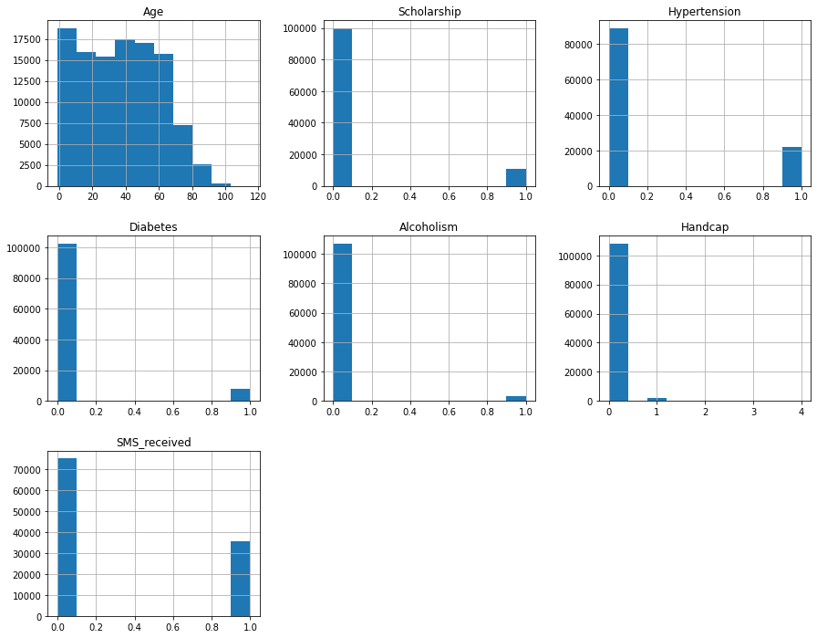

```python
# histgram of all data
df.hist(figsize=(15,12));
```

most of patient did not suffer from chronic diseases nor handicapped Patients who received mobile messages were half of those who did not small persentage(around 9%) are enrolled in welfare program

```python
# convert yes and no to show and no show
show=df.No_show=='No'
noshow=df.No_show=='Yes'
```

```
The number of those who showed 4 times who did not show at the clinic
```

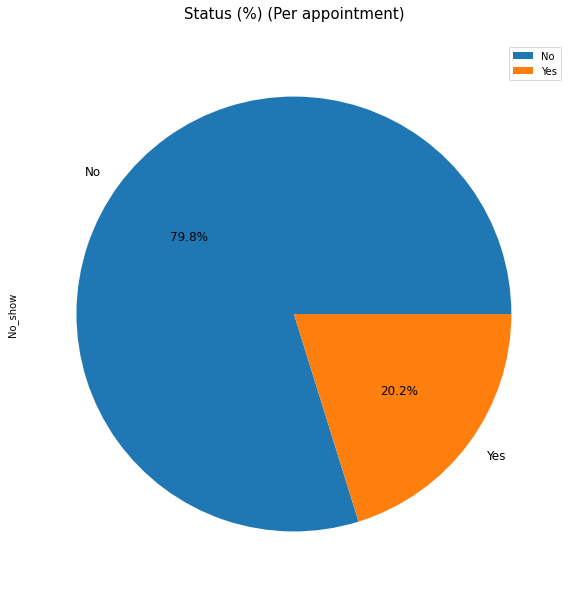

```python
apoint = df['No_show'].value_counts()
pieChart = apoint.plot.pie(figsize=(10,10), autopct='%1.1f%%', fontsize = 12);
plt.title("Status" + ' (%) (Per appointment)\n', fontsize = 15)
plt.legend();
print('The number of those who showed 4 times who did not show at the clinic')
```

The number of those who showed 4 times who did not show at the clinic

```python
df[show].count()
```

```
Gender           88208
Age              88208
Neighbourhood    88208
Scholarship      88208
Hypertension     88208
Diabetes         88208
Alcoholism       88208
Handcap          88208
SMS_received     88208
No_show          88208
dtype: int64
```

```python
df[noshow].count()
```

```
Gender           22319
Age              22319
Neighbourhood    22319
Scholarship      22319
Hypertension     22319
Diabetes         22319
Alcoholism       22319
Handcap          22319
SMS_received     22319
No_show          22319
dtype: int64
```

The number of those who showed 4 times who did not show at the clinic

Analysing characteristics

```python
# comparison between show and no show according to Gender
```

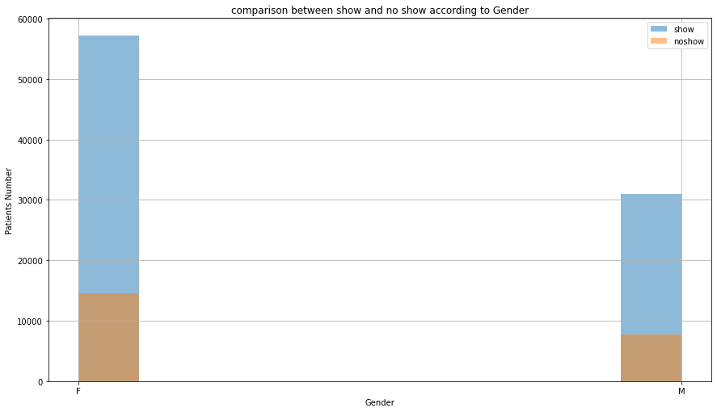

```python
plt.figure(figsize=[14.70,8.27])
df.Gender[show].hist(alpha= 0.5,label='show')
df.Gender[noshow].hist(alpha=0.5,label='noshow')
plt.legend()
plt.title('comparison between show and no show according to Gender')
plt.xlabel('Gender')
plt.ylabel('Patients Number');
```

• the features gender is not a factor to decide if the person would come to his appointment or not!

```python
print(df.Gender[show].value_counts())
```

```
F    57246
M    30962
Name: Gender, dtype: int64
```

```python
print(df.Gender[noshow].value_counts())
```

```
F    14594
M     7725
Name: Gender, dtype: int64
```

Gender is insignificant because female is more than male in show and noshow

```python
#comparison between show and no show according to Scholarship
```

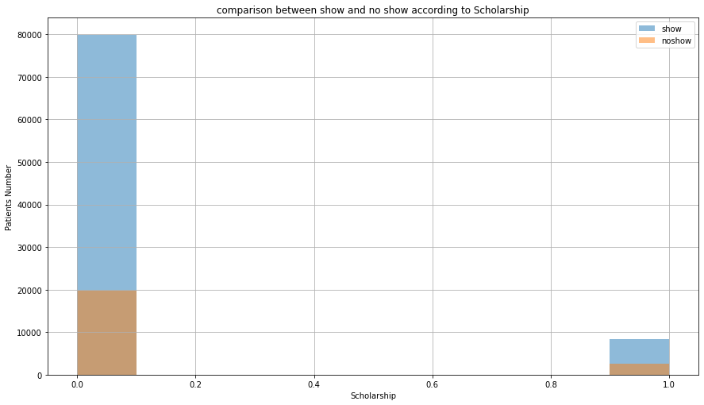

```python
plt.figure(figsize=[14.70,8.27])
df.Scholarship[show].hist(alpha= 0.5,label='show')
df.Scholarship[noshow].hist(alpha=0.5,label='noshow')
plt.legend()
plt.title('comparison between show and no show according to Scholarship')
plt.xlabel('Scholarship')
plt.ylabel('Patients Number');
```

```python
print(df.Scholarship[show].value_counts())
print(df.Scholarship[noshow].value_counts())
```

```
0    79925
1     8283
Name: Scholarship, dtype: int64
0    19741
1     2578
Name: Scholarship, dtype: int64
```

be enrolled in walfare is insignificant

```python
#comparison between show and no show according to Hypertension
```

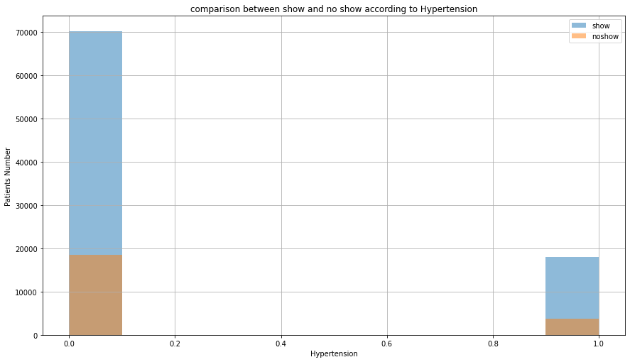

```python
plt.figure(figsize=[14.70,8.27])
df.Hypertension[show].hist(alpha= 0.5,label='show')
df.Hypertension[noshow].hist(alpha=0.5,label='noshow')
plt.legend()
plt.title('comparison between show and no show according to Hypertension')
plt.xlabel('Hypertension')
plt.ylabel('Patients Number');
```

```python
print(df.Hypertension[show].value_counts())
print(df.Hypertension[noshow].value_counts())
```

```
0    70179
1    18029
Name: Hypertension, dtype: int64
0    18547
1     3772
Name: Hypertension, dtype: int64
```

Hypertension insignificant

```python
#comparison between show and no show according to Diabetes
```

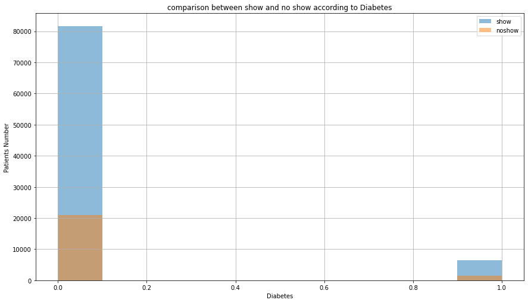

```python
plt.figure(figsize=[14.70,8.27])
df.Diabetes[show].hist(alpha= 0.5,label='show')
df.Diabetes[noshow].hist(alpha=0.5,label='noshow')
plt.legend()
plt.title('comparison between show and no show according to Diabetes')
plt.xlabel('Diabetes')
plt.ylabel('Patients Number');
```

```python
print(df.Diabetes[show].value_counts())
print(df.Diabetes[noshow].value_counts())
```

```
0    81695
1     6513
Name: Diabetes, dtype: int64
0    20889
1     1430
Name: Diabetes, dtype: int64
```

comparison between show and no show according to Diabetes is insignificant

```python
#comparison between show and no show according to Alcoholism
```

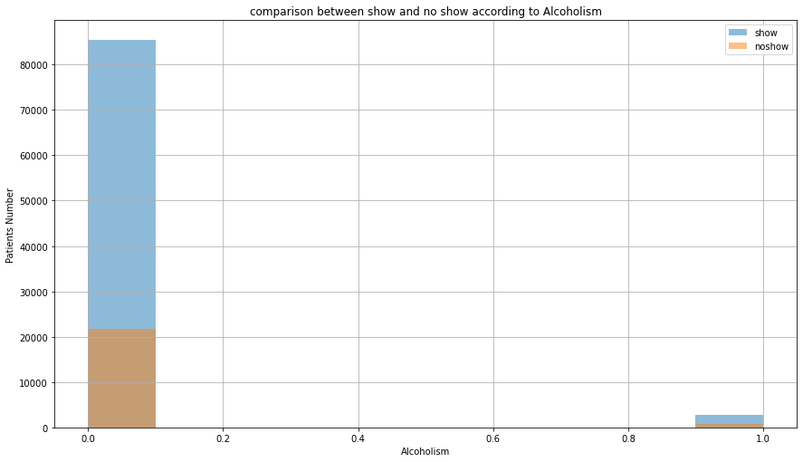

```python
plt.figure(figsize=[14.70,8.27])
df.Alcoholism[show].hist(alpha= 0.5,label='show')
df.Alcoholism[noshow].hist(alpha=0.5,label='noshow')
plt.legend()
plt.title('comparison between show and no show according to Alcoholism')
plt.xlabel('Alcoholism')
plt.ylabel('Patients Number');
```

• the features alcoholic is not a factor to decide if the person would come to his appointment or not!

```python
print(df.Alcoholism[show].value_counts())
print(df.Alcoholism[noshow].value_counts())
```

```
0    85525
1     2683
Name: Alcoholism, dtype: int64
0    21642
1      677
Name: Alcoholism, dtype: int64
```

comparison between show and no show according to Alcoholism is insignificant

```python
#comparison between show and no show according to Handcap
```

[figure not shown]

```python
plt.figure(figsize=[14.70,8.27])
df.Handcap[show].hist(alpha= 0.5,label='show')
df.Handcap[noshow].hist(alpha=0.5,label='noshow')
plt.legend()
plt.title('comparison between show and no show according to Handcap')
plt.xlabel('Hypertension')
plt.ylabel('Patients Number');
```

• this features is not a factor to decide if the person would come to his appointment or not

```python
print(df.Handcap[show].value_counts())
print(df.Handcap[noshow].value_counts())
```

```
0    86374
1     1676
2      146
3       10
4        2
Name: Handcap, dtype: int64
0    21912
1      366
2       37
3        3
4        1
Name: Handcap, dtype: int64
```

comparison between show and no show according to Handcap is insignificant

```python
# comparison between show and no show according to received SMS
```

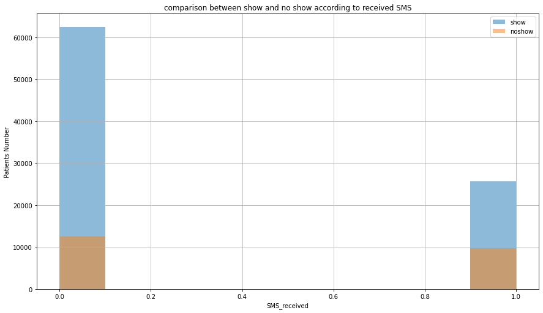

```python
plt.figure(figsize=[14.70,8.27])
df.SMS_received[show].hist(alpha= 0.5,label='show')
df.SMS_received[noshow].hist(alpha=0.5,label='noshow')
plt.legend()
plt.title('comparison between show and no show according to received SMS')
plt.xlabel('SMS_received')
plt.ylabel('Patients Number');
```

As we can see sending an SMS for the appiontment is not neccessary the right option to make sure that the patient will come(It seems strange)

```python
print(df.SMS_received[show].value_counts())
print(df.SMS_received[noshow].value_counts())
```

```
0    62510
1    25698
Name: SMS_received, dtype: int64
0    12535
1     9784
Name: SMS_received, dtype: int64
```

It seems strange that most people attend without receiving messages

```python
# comparison between show and no show according to Age
```

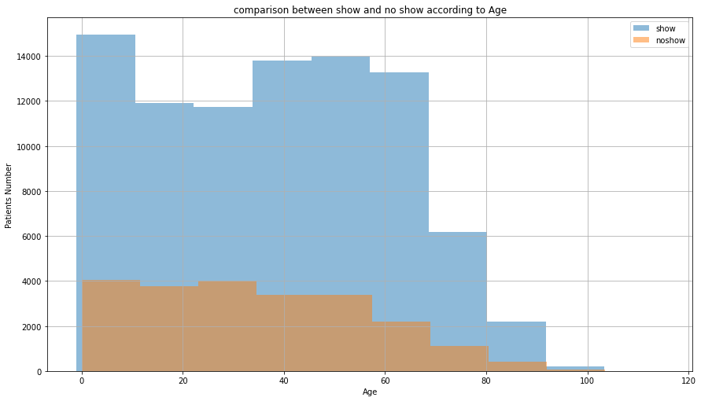

```python
plt.figure(figsize=[14.70,8.27])
df.Age[show].hist(alpha= 0.5,label='show')
df.Age[noshow].hist(alpha=0.5,label='noshow')
plt.legend()
plt.title('comparison between show and no show according to Age')
plt.xlabel('Age')
plt.ylabel('Patients Number');
```

```python
print(df.Age[show].value_counts())
print(df.Age[noshow].value_counts())
```

```
 0      2900
 1      1858
 52     1449
 56     1372
 2      1366
        ...
 100       4
 115       2
 102       2
 99        1
-1         1
Name: Age, Length: 104, dtype: int64
0      639
1      415
17     396
19     394
30     369
      ...
95       6
115      3
97       2
98       1
96       1
Name: Age, Length: 100, dtype: int64
```

patient in age 0-10 showed mor than other age

```python
# comparison between show and no show according to Neighbourhood
```

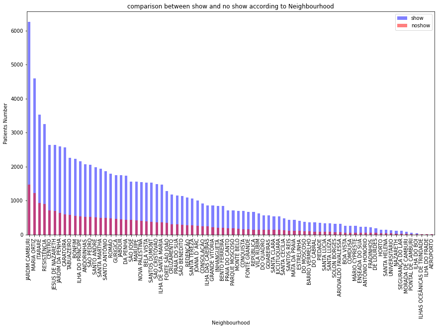

```python
plt.figure(figsize=[14.70,8.27])
df.Neighbourhood[show].value_counts().plot (kind='bar',alpha= 0.5,color='blue',label='show')
df.Neighbourhood[noshow].value_counts().plot (kind='bar',alpha= 0.5,color='red',label='noshow')
plt.legend()
plt.title('comparison between show and no show according to Neighbourhood')
plt.xlabel('Neighbourhood')
plt.ylabel('Patients Number');
```

Conclusions

Limitations:

There can't be a relationship between the patients showed up and a lot of characteristic like gender,chronic,diseases.

```python
from subprocess import call
call(['python', '-m', 'nbconvert', 'Investigate_a_Dataset.ipynb'])
```

```
4294967295
```